# Statistics Group Project Using R

Libby Fortin (efortin@nd.edu), Keith O’Connor (koconn23@nd.edu), Chelsea Weibel (cweibel@nd.edu)

11/27/2017

### Question 1: Evaluating the effect of three different new antibiotics on growth of E. coli in lab cultures.

##### Let’s visualize the data using ggplot. Since the data is categorical we use a boxplot:

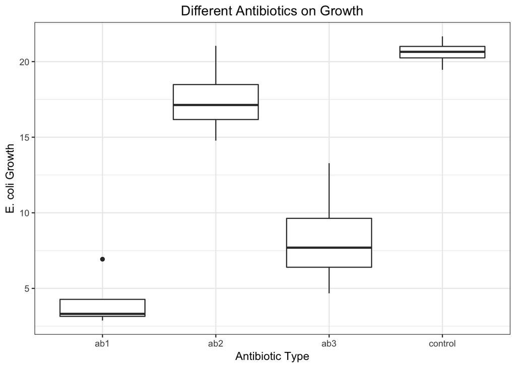

```r
library(ggplot2)

antibiotics <- read.csv("antibiotics.csv")

plot1 <- ggplot(antibiotics, aes(x = trt, y = growth)) +
      geom_boxplot() +
      theme_bw() +
      xlab("Antibiotic Type") + ylab("E. coli Growth") +
      theme(plot.title = element_text(hjust = 0.5)) + # Centers the title
      ggtitle("Different Antibiotics on Growth")

plot1
```

#### Next, we need to look at antibiotic treatments on the growth of E. coli using an ANOVA-design linear model and likelihood ratio test. (11/29/17)

##### To do this we first need to assign a value to the absence of antibiotic treatment and the presence of antibiotic treament

- The easiest way to do this is with a for-loop that assigns a zero to the control treatment, and a one to any of the antibiotic treatments
- The for-loop below adds a column to the antibiotics dataset called ‘aborct’ entering zeros and ones to antibiotic treatment or no antibiotic treatment

```r
for (i in 1:nrow(antibiotics)){
  if (antibiotics$trt[i] == 'control'){
    antibiotics$aborct[i] <- 0
  }
  else{
    antibiotics$aborct[i] <- 1
  }
}
```

##### Next we need to subset the data into matrices that contain only the control data and one of the antibiotic treatments

- These matrices are labeled ab1, ab2, and ab3 for the different types of antibiotics
- For each matrix we add the control data and then below that we add the data for each antibiotic so that we can make comparisons between the control and antibiotic 1, 2, and 3

```r
ab1 <- antibiotics[antibiotics$trt == 'control',]
ab1[5:8,] <- antibiotics[antibiotics$trt == 'ab1',]

ab2 <- antibiotics[antibiotics$trt == 'control',]
ab2[5:8,] <- antibiotics[antibiotics$trt == 'ab2',]

ab3 <- antibiotics[antibiotics$trt == 'control',]
ab3[5:8,] <- antibiotics[antibiotics$trt == 'ab3',]
```

##### It’s easiest to keep our results of the negative log likelihood models and the likelihood ratio test organized if we create a matrix that holds all the results

- Below we create a matrix where column 1 holds the results of the null model, column 2 holds the results of the linear model, and column 3 holds the results of the likelihood ratio test

```r
results <- matrix(0,3,3)
colnames(results) <- c("null", "linear", "chisq")
```

##### Now we are ready to define our negative log likelihood functions, one for the null model and one for the linear model

- The null model hypothesizes that there is no relationship between antibiotics and growth
- The linear model hypothesizes that there is a linear relationship between antibiotics and growth

```r
#Null model function
nllnull <- function(p,y){
  B0=p[1]
  sig=exp(p[2])
  expected=B0
  nll=-sum(dnorm(x=y, mean=expected, sd=sig,log=TRUE))
  return(nll)
}

#Linear Model function
nlllinear <- function(p,x,y){
  B0=p[1]
  B1=p[2]
  sig=exp(p[3])
  expected=B0+B1*x
  nll=-sum(dnorm(x=y, mean=expected, sd=sig,log=TRUE))
  return(nll)
}
```

##### We are ready to run the null and linear negative log likelihood models for the three different antibiotic treatments and store them in our results table

```r
# Antibiotic 1 null model and linear model results
initialGuess <- c(1,1)
fit <- optim(par=initialGuess,fn=nllnull,y=ab1$growth)
results[1,1] <- fit$value

initialGuess <- c(1,1,1)
fit <- optim(par=initialGuess,fn=nlllinear,x=ab1$aborct,y=ab1$growth)
results[1,2] <- fit$value

# Antibiotic 2 null model and linear model results
initialGuess <- c(1,1)
fit <- optim(par=initialGuess,fn=nllnull,y=ab2$growth)
results[2,1] <- fit$value

initialGuess <- c(1,1,1)
fit <- optim(par=initialGuess,fn=nlllinear,x=ab2$aborct,y=ab2$growth)
results[2,2] <- fit$value

# Antibiotic 3 null model and linear model results
initialGuess <- c(1,1)
fit <- optim(par=initialGuess,fn=nllnull,y=ab3$growth)
results[3,1] <- fit$value

initialGuess <- c(1,1,1)
fit <- optim(par=initialGuess,fn=nlllinear,x=ab3$aborct,y=ab3$growth)
results[3,2] <- fit$value
```

##### Finally we calculate the likelihood ratio test and store the results in our results table

```r
#likelihood ratio test results
A <- 2*(results[1,1]-results[1,2])
B <- 2*(results[2,1]-results[2,2])
C <- 2*(results[3,1]-results[3,2])
results[1,3] <- pchisq(q=A, df=1, lower.tail=FALSE)
results[2,3] <- pchisq(q=B, df=1, lower.tail=FALSE)
results[3,3] <- pchisq(q=C, df=1, lower.tail=FALSE)
results
```

```
##          null   linear        chisq
## [1,] 28.32768 13.37281 4.526327e-08
## [2,] 18.01163 15.61857 2.868993e-02
## [3,] 26.38841 18.00736 4.237109e-05
```

##### All of the antibiotic treatments have a significant effect on growth because the chi squared values are all less than 0.05!

### Question 2: Evaluating the effect of sugar concentration on growth of E. coli in lab cultures.

[figure not shown]

```r
#### Linear plot of sugar effects on growth with line equation and R2 ####

library(ggplot2)

sugardata <- read.csv(file = "sugar.csv", header=TRUE)

plot2 <- ggplot(data = sugardata, aes(x = sugar, y = growth))+
  geom_point(color = "blue1", shape = 16, size = 2) +
  theme_classic() +
  xlab("Sugar Concentration") + ylab("E. coli Growth") +
  ggtitle("Effect of Sugar Concentration on Growth of E. coli") +
  theme(plot.title = element_text(hjust = 0.5)) + #Centers the title
  stat_smooth(method = "lm", se=FALSE, color="black") + #Adds a trend line, se=FALSE gets rid of cloud around trendline.
  geom_text(aes(x = 5, y = 25, label = lm_eqn1(lm(sugar ~ growth, sugardata))), parse = TRUE) # Adds the values for the R2 value and equation of the trendline to the coordinates x and y

m= lm(sugar ~ growth, sugardata)

lm_eqn1 = function(m) {       #Function to calculate and add R2 value and equation of the trendline to plot

  l <- list(a = format(coef(m)[1], digits = 2),
            b = format(abs(coef(m)[2]), digits = 2),
            r2 = format(summary(m)$r.squared, digits = 3));

  if (coef(m)[2] >= 0)  {
    eq <- substitute(italic(y) == a + b %.% italic(x)*","~~italic(r)^2~"="~r2,l)
  } else {
    eq <- substitute(italic(y) == a - b %.% italic(x)*","~~italic(r)^2~"="~r2,l)
  }

  as.character(as.expression(eq));
}

plot2
```

#### Next, we need test for an effect of sugar concentration on growth of E. coli using a regression-design linear model and likelihood ratio test. (11/29/17)

```r
#### Likelihood ratio test

############## Null model
# Null hypothesis = the growth of E. coli is the same regardless of the sugar concentration

nllnull = function(p,y){
  B0=p[1]
  sig=exp(p[2])
  expected=B0
  nll=-sum(dnorm(x=y, mean=expected, sd=sig,log=TRUE))
  return(nll)
}

initialGuess = c(5,1)
null = optim(par=initialGuess,fn=nllnull,y=sugardata$growth)
print(null)
```

```
## $par
## [1] 9.050503 2.096191
##
## $value
## [1] 56.2412
##
## $counts
## function gradient
##       61       NA
##
## $convergence
## [1] 0
##
## $message
## NULL
```

```r
################ Linear Model
# Alternative hypothesis = the growth of E. coli is dependent on the sugar concentration

nllike_linear=function(p,x,y){
  B0=p[1]
  B1=p[2]
  sigma=exp(p[3])

  expected=B0+B1*x

  nll_linear=-sum(dnorm(x=y,mean=expected,sd=sigma,log=TRUE))
  return(nll_linear)
}

initialGuess=c(5,1,1)
fit_linear=optim(par=initialGuess,fn=nllike_linear,x=sugardata$sugar,y=sugardata$growth)

print(fit_linear)
```

```
## $par
## [1] -0.8506007  1.7303515  0.8485841
##
## $value
## [1] 36.27864
##
## $counts
## function gradient
##      144       NA
##
## $convergence
## [1] 0
##
## $message
## NULL
```

```r
############# likelihood ratio test
q = 2*(null$value-fit_linear$value)
lrt = pchisq(q=q, df=1, lower.tail=FALSE)
print(lrt)
```

```
## [1] 2.638879e-10
```

```r
# Becuase the p-value is less than 0.05 (2.64e-10), this means that we can reject the null hypothesis and conclude that there is a significant effect of sugar concentration on E. coli growth
```

### Statistical_Power_Analysis

```r
#### A statistical power analysis ####
library(ggplot2)

num_sims <- 10 # Simulate the data 10 times
n_per_sim <- 24 # Each simulation will have 24 values
set.seed(24) # Seed is necessary for reproducibility
sigma <- c(1,2,4,6,8,12,16,24)

matrix_outputx <- matrix(NA, ncol=n_per_sim, nrow=num_sims) # This creates a 10x24 matrix for the simulated x-values
matrix_outputy <- matrix(NA, ncol=n_per_sim, nrow=num_sims) # This creates a 10x24 matrix for the simulated y-values

for (sim_number in 1:num_sims){ # This starts your for loop
  x <- sample(x = 0:50, size = 24) # Creates a random generation of 24 x-values between 0 and 50
  m <- 0.4 # Given slope value
  b <- 10 # Given y-intercept
  y <- m*x + b # Calculates y-values from the 24 randomly generated x-values using given slope and intercept

  for (sigma_number in 1:8){
    y = y+rnorm(n_per_sim, sd=sigma)
  }

  matrix_outputx[sim_number, ] <- x # This is where each x output is stored for each simulation
  matrix_outputy[sim_number, ] <- y # This is where each y output is stored for each simulation
}
matrix_outputx # Shows the output for the 10 x 24 matrix for the simulated x-values
```

```
##       [,1] [,2] [,3] [,4] [,5] [,6] [,7] [,8] [,9] [,10] [,11] [,12] [,13]
##  [1,]   14   11   34   24   31   42   12   33   48    10    47    50    26
##  [2,]    6   34   30   38   31   48   40    0   10    14    47    24    43
##  [3,]   12   19   11   21    5   17   41   39   16    46    32     0    29
##  [4,]   47   23   28   24   36   13   22   48   21    27    33    37     1
##  [5,]   37   23   22   16    3   43   41   10   46    34    12    26    19
##  [6,]   26   23    7   36   37   43   13   11   39    45    15    41     0
##  [7,]   18    3    6    5   33   45    2   19   31    12    50    32    21
##  [8,]    4   13    0   27   15   25   16   32   49    42    14    50    19
##  [9,]   21   48   35    5   14   39   12   10   50    37    27     4    30
## [10,]   44    4   21    9   42   29   16   30   23    43    31    50    38
##       [,14] [,15] [,16] [,17] [,18] [,19] [,20] [,21] [,22] [,23] [,24]
##  [1,]    25    49    32     6     1    16     4     2    35    21     3
##  [2,]    50    42    37     8    44    46    39    20    28    36    23
##  [3,]    18    34    13    36    33    26    35    25    50    23    20
##  [4,]    11    43    44    32    50    20    31     8    41    38     7
##  [5,]    44    15    30    33     4    36    11    49    17    20     5
##  [6,]    30    34     9    24    47    10    32    48     8    42    40
##  [7,]    35     0    16    29    26     8    24    38    22    41    11
##  [8,]     6    17     9    47    18    35     5    23     1    26    44
##  [9,]    34    18    22    20    26     8    33    19    40    24    45
## [10,]    35    33    34     2     7     8    46    36    32    13     0
```

```r
matrix_outputy # Shows the output for the 10 x 24 matrix for the simulated y-values
```

```
##           [,1]      [,2]      [,3]        [,4]        [,5]       [,6]
##  [1,] 10.49852 19.900386 27.504251 19.70617902   7.8015390  13.539975
##  [2,] 13.08446 28.493628 31.538970  5.05234825  33.0716275 -39.535726
##  [3,] 11.34929 17.264902 28.790329 30.25868710  10.0833677  44.700050
##  [4,] 29.79533 23.988351 26.094515 -7.13651873  10.3103551 -17.381522
##  [5,] 26.11416 17.162114 15.206104 -8.40821844 -17.2024514   4.864103
##  [6,] 21.99504 14.948975 15.562055  0.02954849  -0.7114859  42.588404
##  [7,] 16.20763  9.494891 24.312998 -8.49468449  -9.7223181 -25.126393
##  [8,] 10.79292  2.158755 19.132275 24.59120217  20.7471410  33.554336
##  [9,] 24.98039 39.751095 -4.011559 10.62210134  23.6302336  13.536417
## [10,] 24.17877 20.565922  6.994441  9.76676667  10.9311478  10.075206
##             [,7]       [,8]     [,9]     [,10]     [,11]      [,12]
##  [1,] -67.585938 -89.718061 29.48865  7.929767 18.439512  35.709549
##  [2,]  56.471257  57.026173 15.01738  8.209669  8.721232 -12.129667
##  [3,]   7.239732 196.301862 14.69362 25.384877 21.338101  -4.452854
```

[output cut: 29 more lines]

```r
############## I THINK THIS WORKS!!!! #####################
num_sims <- 10 # Simulate the data 10 times
n_per_sim <- 24 # Each simulation will have 24 values
set.seed(24) # Seed is necessary for reproducibility
sigma_num <- 8
sigma <- c(1,2,4,6,8,12,16,24)

outputx<-as.data.frame(matrix(0, ncol=10, nrow=24))
outputy<-as.data.frame(matrix(0, ncol=10, nrow=24))
youtput <-list()

for (sim_number in 1:num_sims){ # This starts your for loop
  x = sample(x = 0:50, size = 24) # Creates a random generation of 24 x-values between 0 and 50
  m <- 0.4 # Given slope value
  b <- 10 # Given y-intercept
  y <- m*x + b # Calculates y-values from the 24 randomly generated x-values using given slope and intercept
  outputx[,sim_number] <- x

for (sigma_number in 1:sigma_num){
   outputy = y+rnorm(length(y), mean=0, sd=sigma[sigma_number])
   youtput[[sigma_number]] <- outputy
  }
}



#### Linear Regression ####




#### ANOVA ####
############## THIS SHOULD WORK TOO!!!!

# 2-level design
x = c(13,13,13,13,13,13,13,13,13,13,13,13,38,38,38,38,38,38,38,38,38,38,38,38)
x_values = matrix(rep(x,10),nrow=24,ncol=10)
num_sims <- 10 # Simulate the data 10 times
n_per_sim <- 24 # Each simulation will have 24 values
set.seed(24) # Seed is necessary for reproducibility
sigma_num <- 8
sigma <- c(1,2,4,6,8,12,16,24)

y <- .4 * x_values + 10

outputy<-as.data.frame(matrix(0, ncol=10, nrow=24))
youtput <-list()

  for (sigma_number in 1:sigma_num){
    outputy = y + rnorm(length(y), mean=0, sd=sigma[sigma_number])

    youtput[[sigma_number]] <- outputy
  }
```